# 210517_HeatmapsOfRelevantGenes_CohenSharir

Erin Osborne Nishimura

5/17/2021

# Analysis: Heatmaps of key gene signature sets

The purpose of this analysis is to assess how gene signature sets are changing in the Cohen-Sharir, 2021 datasets. Previous publications have reported the transcriptional profiles associated with different types of pathway activation.

The Cohen-Sharir Dataset is here:

- Cohen-Sharir Y, McFarland JM, Abdusamad M, Marquis C, Bernhard SV, Kazachkova M, Tang H, Ippolito MR, Laue K, Zerbib J, Malaby HLH, Jones A, Stautmeister LM, Bockaj I, Wardenaar R, Lyons N, Nagaraja A, Bass AJ, Spierings DCJ, Foijer F, Beroukhim R, Santaguida S, Golub TR, Stumpff J, Storchová Z, Ben-David U. [Aneuploidy renders cancer cells vulnerable to mitotic checkpoint inhibition](https://doi:%2010.1038/s41586-020-03114-6) *Nature* **2021** Feb;590(7846):486-491.

For this analysis, we used the following publications:

- Creighton CJ. [A gene transcription signature of the Akt/mTOR pathway in clinical breast tumors](https://doi.org/10.1038/sj.onc.1210245). *Oncogene* **2007**;26:4648–55.
- Dry JR, Pavey S, Pratilas CA, Harbron C, Runswick S, Hodgson D, et al. [Transcriptional Pathway Signatures Predict MEK Addiction and Response to Selumetinib (AZD6244)](https://doi.org/10.1158/0008-5472.can-09-1577). *Cancer Res* **2010**;70:2264–73.
- Loboda A, Nebozhyn M, Klinghoffer R, Frazier J, Chastain M, Arthur W, et al. [A gene expression signature of RAS pathway dependence predicts response to PI3K and RAS pathway inhibitors and expands the population of RAS pathway activated tumors.](https://doi.org/10.1186/1755-8794-3-26) *Bmc Med Genomics* **2010**;3:26.
- Pratilas CA, Taylor BS, Ye Q, Viale A, Sander C, Solit DB, et al. [V600EBRAF is associated with disabled feedback inhibition of RAF–MEK signaling and elevated transcriptional output of the pathway.](https://doi.org/10.1073/pnas.0900780106) *Proc National Acad Sci* **2009**;106:4519–24.
- Wagle M-C, Kirouac D, Klijn C, Liu B, Mahajan S, Junttila M, et al. [A transcriptional MAPK Pathway Activity Score (MPAS) is a clinically relevant biomarker in multiple cancer types](https://doi.org/10.1038/s41698-018-0051-4). *Npj Precis Oncol* **2018**;2:7.

## Step 1: Load packages

```r
library(RColorBrewer)
library(ggplot2)
library(dplyr)
library(pheatmap)
library(reshape2)
library(pryr)
```

## Step 2: Set Today’s date:

```
## [1] "210522"
```

## Step 3: Import the data from CohenSharir -

```r
# This was an output from: 210128_DESeq_analyze_EONversion
cohen_sharir <- read.table(file = "../01_input/41586_2020_3114_MOESM6_ESM.txt", header = TRUE)

UpInCohenSharir <- rownames(cohen_sharir %>%
    filter(q_value < 0.05) %>%
      filter(Effect_size > 0 ))
length(UpInCohenSharir)
```

```
## [1] 4898
```

```r
print("How many genes are over-expressed in the Cohen-Sharir dataset?")
```

```
## [1] "How many genes are over-expressed in the Cohen-Sharir dataset?"
```

```r
length(UpInCohenSharir)
```

```
## [1] 4898
```

```r
DownInCohenSharir <- rownames(cohen_sharir %>%
    filter(q_value < 0.05) %>%
      filter(Effect_size < 0 ))
length(DownInCohenSharir)
```

```
## [1] 5142
```

```r
#DownInCohenSharir
```

## Step 4: Import the datasets from other published papers -

```r
# Import Mek dataset
Mek18 <- read.table(file = "../01_input/MekEtAl18.txt", header = FALSE)
colnames(Mek18)[1] <- "genenames"

# Import Pratilas dataset
Pratilas_table <- read.table(file = "../01_input/Pratilis_genenames.txt", header = FALSE)
colnames(Pratilas_table)[1] <- "genenames"

# Wagle et al -> 10 genes
vector_of_genes_wagle <- c("SPRY2", "SPRY4", "ETV4", "ETV5", "DUSP4", "DUSP6", "CCND1", "EPHA2", "EPHA4", "PHLDA1")

# Import Creighton dataset
creighton_table <- read.table(file = "../01_input/Creighton_list.txt", header = FALSE)
colnames(creighton_table)[1] <- "genenames"

# Import Loboda dataset
lobodaUp_table <- read.table(file = "../01_input/Loboda_RASUp.txt", header = FALSE)
colnames(lobodaUp_table)[1] <- "genenames"
```

## Step 5: Write some functions:

Write a function called *make_contingency_table* that creates contingency tables for statistical analyses:

Write a function called *vector_of_p_values* that creates a vector of p-values generated from comparisons with the DESeq2 differentially expressed genes expressing the likeliness that a given gene signature set of genes are **enriched** amongst the list of genes.

Write a function called *vector_of_depletion_p_values* that creates a vector of p=values generated from comparisons with the DESeq2 differentially expressed genes expressing the likeliness that a given gene signature set of genes are **depleted** amongst the list of genes.

```
## [1] 0.06420196 0.89877428
```

## Step 6: Write some functions:

Write a function called *calculate_percent_enrichment* that calculates the over-representation of a published gene signature set of genes within the gene sets from GME RNA-seq analysis. The gene sets lists here are up-regulated genes published in Cohen-Sharir et al. that we determined were over-expressed in these cells.

Write a function called *calculate_fold_enrichment* that calcualets the fold enrichment between a published genes signature set and the genesets from our RNA-seq analysis.

## Step 7: Gather statistics:

```
## [1] "P-values of the significance of enrichment"
```

```
##                        UpInCohenSharir DownInCohenSharir
## Dry_et_al_mek_18          6.420196e-02         0.8987743
## Pratilas_et_al_mek_50     2.383163e-01         0.6698892
## Wagle_et_al_mek_10        4.032983e-03         1.0000000
## Creighton_et_al_akt_57    1.107288e-04         0.9998424
## Loboda_ras_101            4.033732e-15         0.9999999
```

```
## [1] "Actual percents of of enrichment"
```

```
##                        UpInCohenSharir DownInCohenSharir Genomewide
## Dry_et_al_mek_18             0.1633320        0.05834306 0.09402424
## Pratilas_et_al_mek_50        0.3266639        0.25281991 0.27162557
## Wagle_et_al_mek_10           0.1429155        0.00000000 0.05223569
## Creighton_et_al_akt_57       0.5716619        0.09723843 0.29774342
## Loboda_ras_101               1.3270723        0.15558149 0.54847472
```

```
## [1] "Fold change of of enrichment"
```

```
##                        UpInCohenSharir
## Dry_et_al_mek_18              1.737126
## Pratilas_et_al_mek_50         1.202626
## Wagle_et_al_mek_10            2.735974
## Creighton_et_al_akt_57        1.919982
## Loboda_ras_101                2.419569
```

```
## [1] "Fold depletion"
```

```
##                        DownInCohenSharir
## Dry_et_al_mek_18               0.6205108
## Pratilas_et_al_mek_50          0.9307662
## Wagle_et_al_mek_10             0.0000000
## Creighton_et_al_akt_57         0.3265846
## Loboda_ras_101                 0.2836621
```

## Step 8: Barplots of enrichment/Depletion

Plot some barplots to illustrate the percentage of each Cohen-Sharir up-regulated genes and their representation in each published gene signature set.

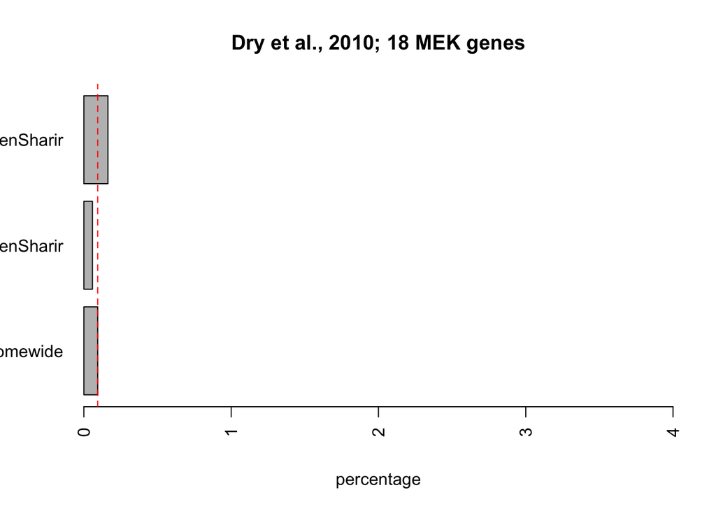

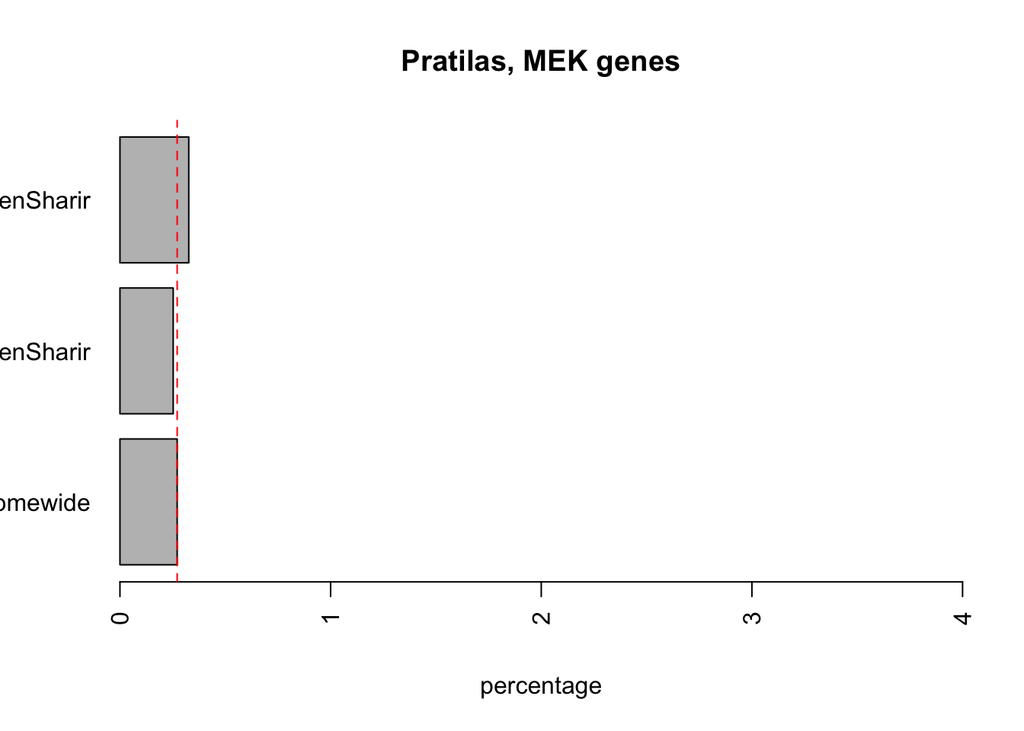

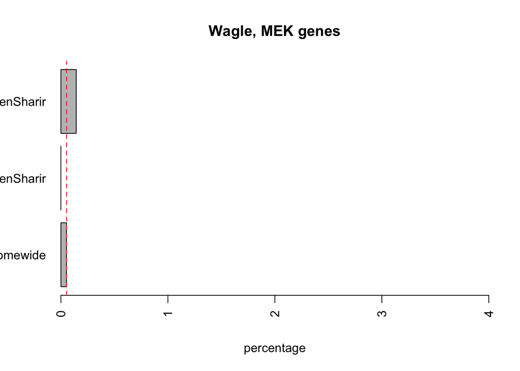

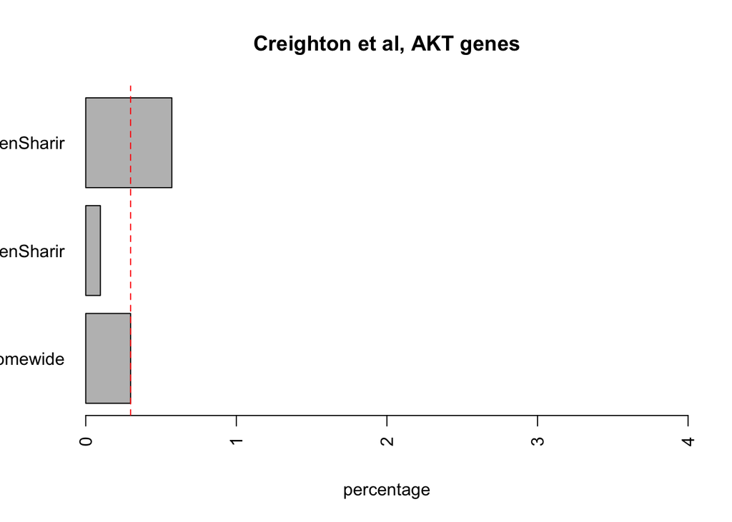

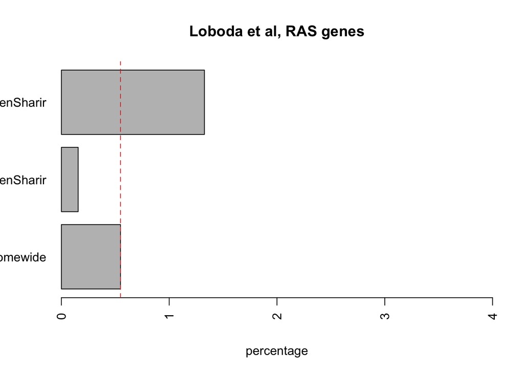

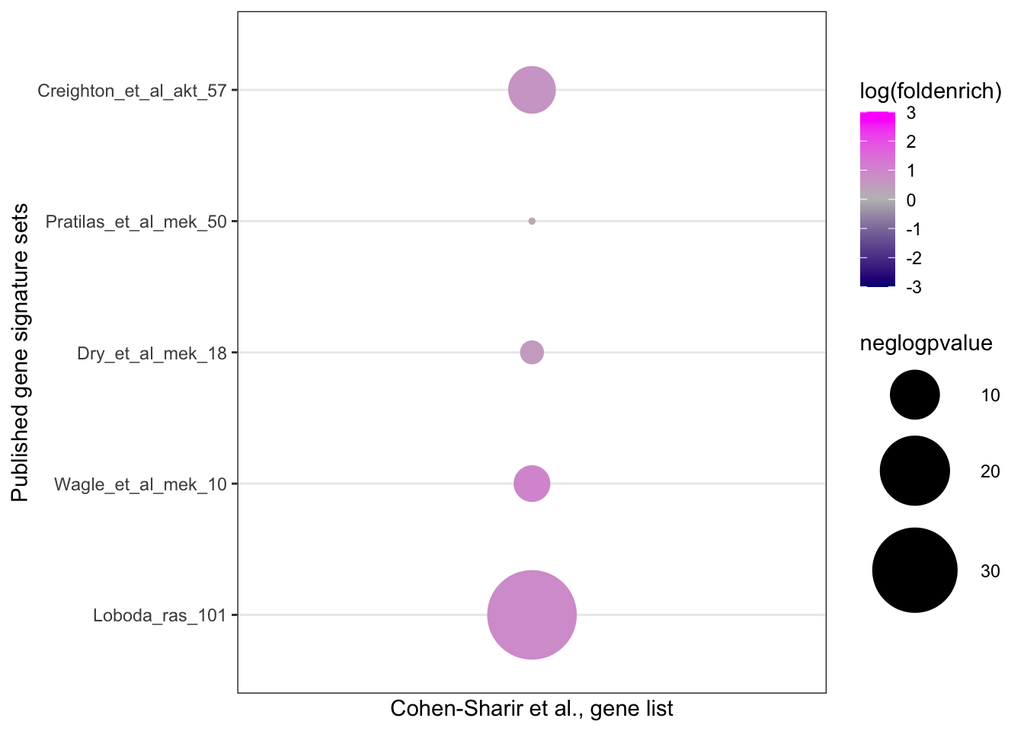

```r
citation()
```

```
##
##
##   R Core Team (2020). R: A language and environment for statistical
##   computing. R Foundation for Statistical Computing, Vienna, Austria.
##   URL https://www.R-project.org/.
##
## A BibTeX entry for LaTeX users is
##
##   @Manual{,
##     title = {R: A Language and Environment for Statistical Computing},
##     author = {{R Core Team}},
##     organization = {R Foundation for Statistical Computing},
##     address = {Vienna, Austria},
##     year = {2020},
##     url = {https://www.R-project.org/},
##   }
##
## We have invested a lot of time and effort in creating R, please cite it
## when using it for data analysis. See also 'citation("pkgname")' for
## citing R packages.
```